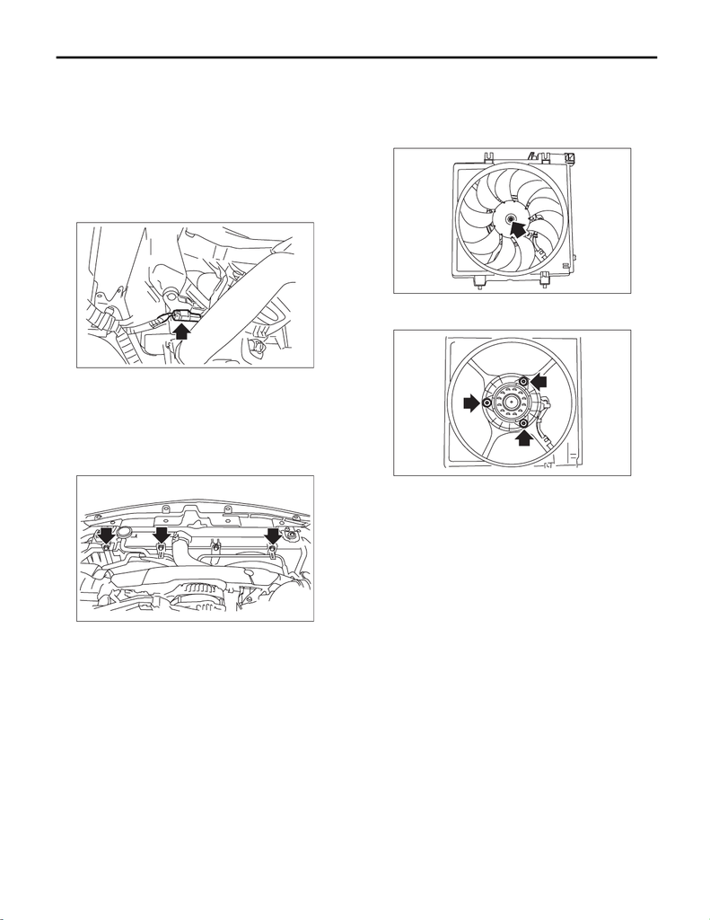

CO(STI)-23

Radiator Main Fan and Fan Motor

COOLING

8. Radiator Main Fan and Fan

Motor

A: REMOVAL

1) Disconnect the ground cable from battery.

2) Lift up the vehicle.

3) Remove the under cover. <Ref. to EI-21, RE-

MOVAL, Front Under Cover.>

4) Disconnect the connector from the main fan mo-

tor.

5) Lower the vehicle.

6) Remove the air intake duct. <Ref. to IN(STI)-11,

REMOVAL, Air Intake Duct.>

7) Remove the reservoir tank. <Ref. to CO(STI)-27,

REMOVAL, Reservoir Tank.>

8) Remove the bolts which secure the radiator

main fan motor assembly and the over flow pipe.

9) Remove the radiator main fan motor assembly

from the upper side of the vehicle.

B: INSTALLATION

Install in the reverse order of removal.

CAUTION:

Check if the radiator hose and the over flow

hose are properly connected.

Tightening torque:

7.5 N·m (0.8 kgf-m, 5.5 ft-lb)

C: DISASSEMBLY

1) Remove the clip which holds the main fan motor

connector onto the radiator main fan shroud.

2) Disconnect the radiator main fan from the main

fan motor.

3) Disconnect the main fan motor from the radiator

main fan shroud.

CO-02776

CO-02412

CO-02372

CO-02373

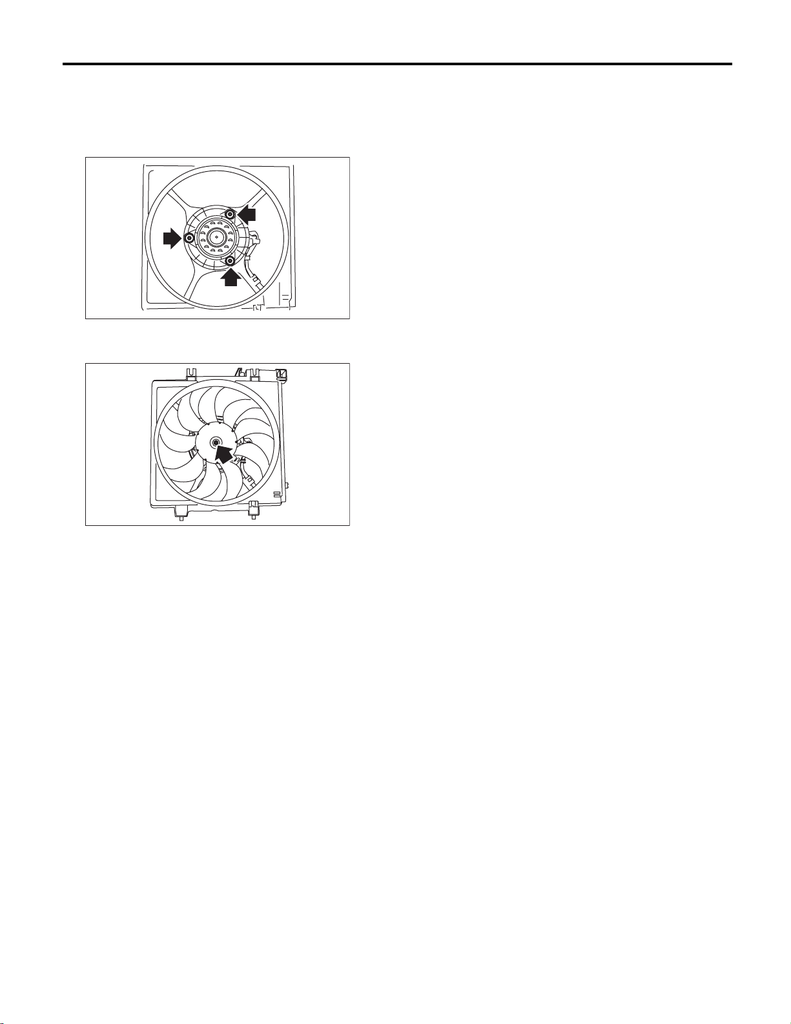

CO(STI)-24

Radiator Main Fan and Fan Motor

COOLING

D: ASSEMBLY

Assemble in the reverse order of disassembly.

Tightening torque:

4.41 N·m (0.45 kgf-m, 3.25 ft-lb)

E: INSPECTION

Check that the radiator main fan, radiator main fan

shroud and main fan motor do not have deforma-

tion, cracks or damage.

CO-02373

CO-02372